# Module 1 Report

## 2.3 Provide some general demographic information about your sample.

```r
demo_data <- data[,c("Year", "Region", "Gender", "Age", "Country", "New Zealand European", "Maori", "Samoan", "Cook Islands Maori", "Tongan", "Niuean", "Chinese", "Indian", "Other ethnicity", "Languages spoken")]
```

### 2.3.1 School Year

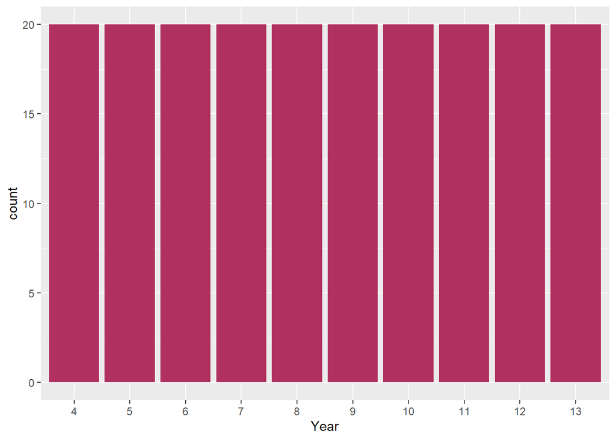

```r
ggplot(demo_data, aes(Year)) + geom_bar(fill="maroon")
```

We can see from the above graph that there is an equal number of students in each year ranging from year 4 to 13 as per the specifications for this report.

### 2.3.2 Region

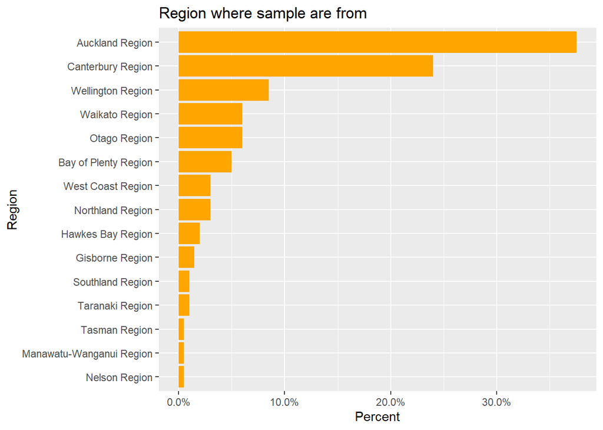

```r
ggplot(demo_data) +
  geom_bar(aes(x=fct_rev(fct_infreq(Region)), y = (..count..)/sum(..count..)), fill="orange") +
  scale_y_continuous(labels=scales::percent) + coord_flip() +
  labs(title = "Region where sample are from", x = "Region", y="Percent")
```

As we can see by the above graph, the highest percentage of respondents come from Aukland, then Canterbury (part of Christchurch), then Wellington. As more than half of our sample population comes from major cities, this report will be cautious in reporting on findings that may be confounded by rural participants.

### 2.3.3 Gender

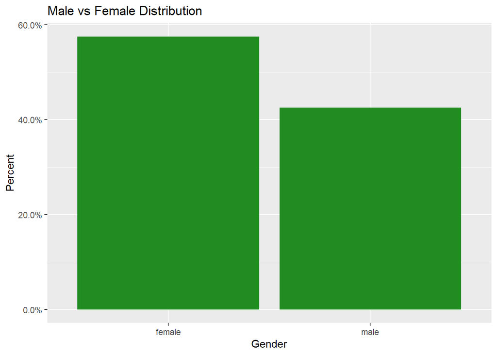

```r
ggplot(demo_data, aes(Gender)) +
  geom_bar(aes(y=(..count..)/sum(..count..)), fill="forest green") +
    scale_y_continuous(labels=scales::percent) +
    labs(title="Male vs Female Distribution", x="Gender", y="Percent")
```

### 2.3.4 Age

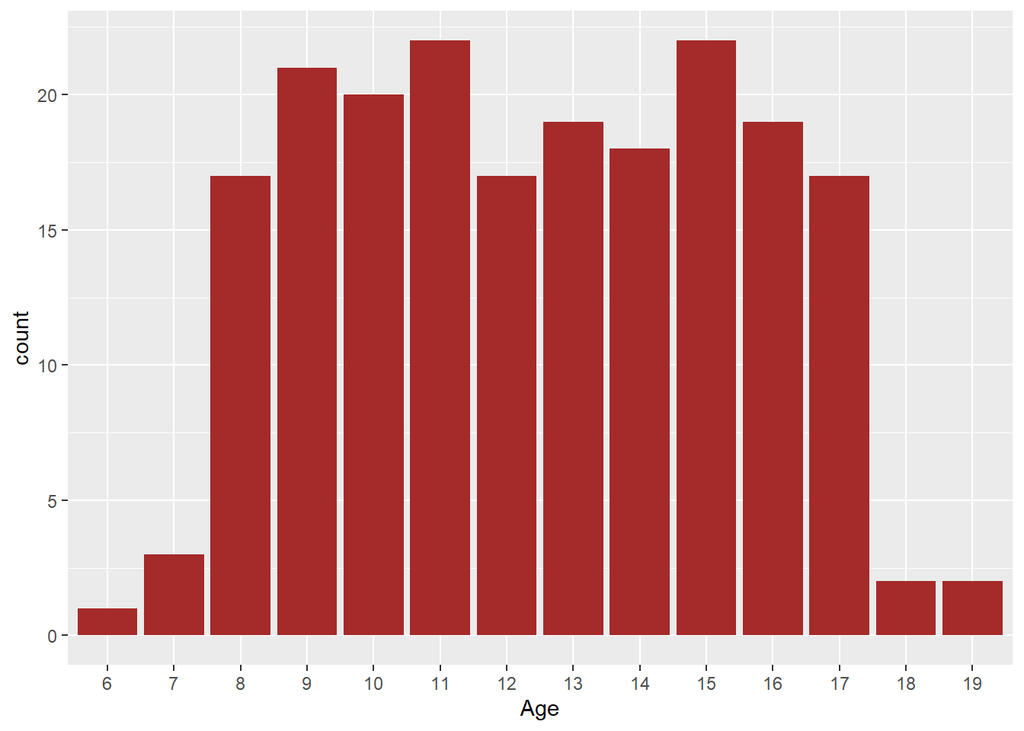

```r
ggplot(demo_data, aes(Age)) +
  geom_bar(fill="brown")
```

We can see that many of our respondents lie between the age of 8 and 17…

### 2.3.5 Nationality

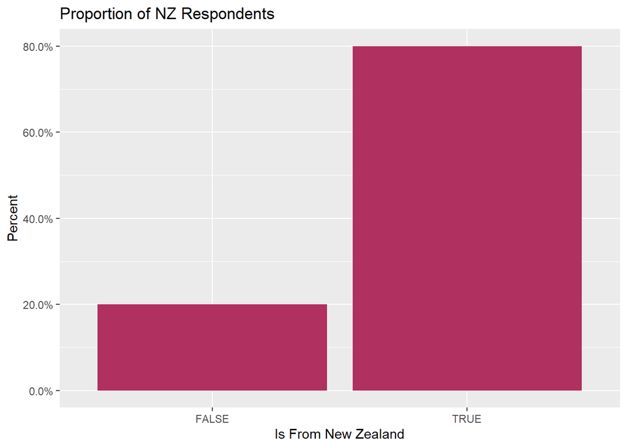

```r
nationality <- as.data.frame((table(demo_data$Country == "New Zealand")))
colnames(nationality) <- c("is_NZ", "freq")
nationality$freq <- nationality$freq/sum(nationality$freq)
ggplot(nationality, aes(x=is_NZ, y=freq)) +
  geom_bar(stat="identity", fill="maroon") +
  scale_y_continuous(labels= scales::percent) +
  labs(title="Proportion of NZ Respondents", x="Is From New Zealand", y="Percent")
```

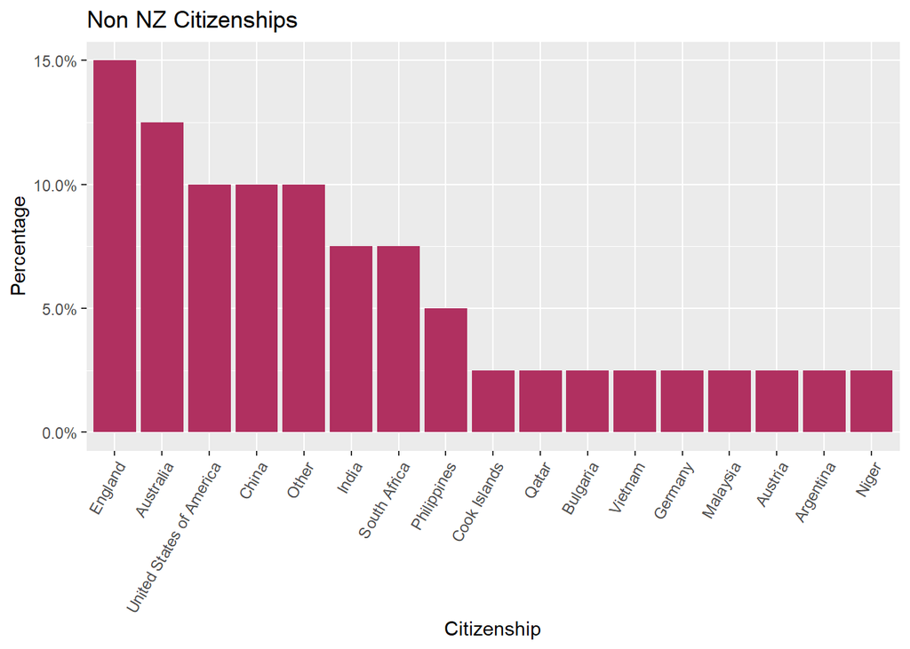

```r
other_c <- subset(demo_data, Country != "New Zealand")
ggplot(other_c, aes(fct_infreq(Country))) +
  geom_bar(aes(y=(..count..)/sum(..count..)), fill="maroon") +
  theme(axis.text.x = element_text(angle=60, hjust=1)) +
  scale_y_continuous(labels=scales::percent) +
  labs(title="Non NZ Citizenships", x="Citizenship",   y="Percentage")
```